# Tópico 3 - Vetores

## Anderson M Amaral - amamaral.github.io/teaching

[figure not shown]

# Vetores

### Fundamentos da Física, Capítulo 3

### Leituras complementares:

- Nussenzveig - Capítulo 3
- Feynman, Leighton, Sands - Capítulo 11

## Movimento de corpos

Já sabemos como descrever o movimento ao longo de retas (1D). E outros movimentos?

[figure not shown]

Ex.: Se uma pessoa se desloca aprox. 100 km a partir do recife, ela pode estar em João Pessoa, Caruaru, Maceió ou mesmo em alto mar...

1D é insufuciente para vários casos de interesse.

## Vetor deslocamento

- Deslocamento no plano de um ponto $A$ para $B$ no espaço.
- Ex.: 100km partindo de Recife.
- Objeto matemático que descreva distância, sentido e direção!
- Vetor é caracterizado por módulo (ou norma), direção e sentido.
- **Vetor deslocamento não depende da trajetória!**

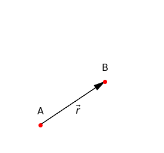

```python
ax = plt.axes()

r = vector2D(dxdy=[0.6, 0.4], label=r'$\vec{r}$')
r.plot(ax)
r.plot_label(ax, relative_position=0.45, distance=-0.1)

plot([0,0.6],[0, 0.4], 'ro')
text(-0.03, 0.1, 'A')
text(0.57 , 0.5, 'B')

xlim(-0.1,1.1)
ylim(-0.1,1.1)
axis('off')
ax.set_aspect('equal')
```

## Propriedades básicas (análise gráfica)

- Soma de vetores ($\vec{a} + \vec{b}$)
- Satisfaz a comutatividade: $\vec{a} + \vec{b} = \vec{b} + \vec{a}$
- Propriedade associativa: $\vec{a} + (\vec{b} + \vec{c}) = (\vec{a} + \vec{b}) + \vec{c}$

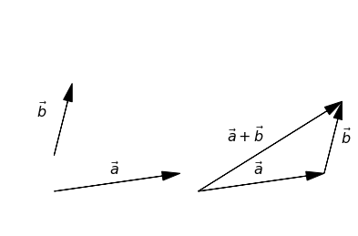

```python
ax = plt.axes()

a = vector2D(dxdy=[0.7,0.1], label=r'$\vec{a}$')
a.plot(ax); a.plot_label(ax, distance=0.05)

b = vector2D(dxdy=[0.1,0.4], label=r'$\vec{b}$')
b.origin = [0, 0.2]
b.plot(ax); b.plot_label(ax, distance=0.15)

new_origin = array([0.8, 0])
a.origin = new_origin
a.plot(ax); a.plot_label(ax, distance=0.05)

b.origin = new_origin + a.dxdy
b.plot(ax); b.plot_label(ax, distance=-0.05)

c = vector2D(dxdy=a.dxdy+b.dxdy, label=r'$\vec{a}+\vec{b}$')
c.origin = new_origin
c.plot(ax); c.plot_label(ax, relative_position=0.3, distance=0.15)

xlim(-0.1,1.6)
ylim(-0.1,1.0)
axis('off')
ax.set_aspect('equal')
```

## Vetores e escalares (números)

- (Escalar)$\cdot$(vetor) = (*outro* vetor).

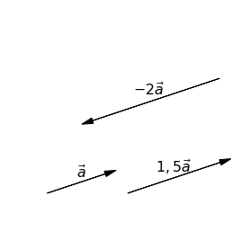

```python
ax = plt.axes()

a_dxdy = array([0.6,0.2])
a = vector2D(origin=[0,0],   dxdy=a_dxdy, label=r'$\vec{a}$')
a.plot(ax); a.plot_label(ax, distance=0.05)

b = vector2D(origin=[0.7,0], dxdy=a_dxdy*1.5, label=r'$1,5\vec{a}$')
b.plot(ax); b.plot_label(ax, relative_position=0.3, distance=0.10)

c = vector2D(origin=[1.5, 1],dxdy=a_dxdy*(-2.), label=r'$-2\vec{a}$')
c.plot(ax); c.plot_label(ax, relative_position=0.6, distance=-0.1)

xlim(-0.1,1.6)
ylim(-0.1,1.6)
axis('off')
ax.set_aspect('equal')
```

## Subtração

- Sinal menos (-) inverte o sentido do vetor.
- Subtração de vetores: $\vec{a} - \vec{b} = \vec{a} + (-\vec{b})$

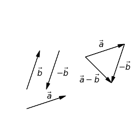

```python
ax = plt.axes()

ax.arrow(0,0,0.6,0.2, **vector_options)
text(0.3 , 0.15, r'$\vec{a}$')

ax.arrow(0,0.3,0.2, 0.6, **vector_options)
text(0.15 , 0.5, r'$\vec{b}$')

ax.arrow(0.5,0.9,-0.2, -0.6, **vector_options)
text(0.45 , 0.5, r'$-\vec{b}$')

ax.arrow(0.9,0.8,0.6,0.2, **vector_options)
text(1.1 , 0.95, r'$\vec{a}$')
ax.arrow(1.5,1.0,-0.2, -0.6, **vector_options)
text(1.4 , 0.6, r'$-\vec{b}$')
ax.arrow(0.9,0.8,0.4, -0.4, **vector_options)
text(0.8 , 0.4, r'$\vec{a}-\vec{b}$')

xlim(-0.1,1.6)
ylim(-0.1,1.6)
axis('off')
ax.set_aspect('equal')
```

## Módulo

- Notação: $|\vec{a}| = a$ é o módulo (norma) de $\vec{a}$.
- Notar que, **em geral**, $$|\vec{a}+\vec{b}|\neq|\vec{a}|+|\vec{b}|$$ $$|\vec{a}-\vec{b}|\neq|\vec{a}|-|\vec{b}|$$
- Quando as relações acima se tornam igualdades?

## Vetores (método analítico)

- Se $\vec{a}=\vec{a}_x+\vec{a}_y$, onde $\vec{a}_x$ e $\vec{a}_y$ são dois vetores paralelos aos eixos $x$ e $y$,
- e são produtos escalares com os vetores unitários $\hat{i}$ e $\hat{j}$:

  $$\vec{a}_x = (a \cos\theta)\hat{i},$$ $$\vec{a}_y = (a \sin\theta)\hat{j}.$$

  $$\vec{a} = (a \cos\theta)\hat{i} + (a \sin\theta)\hat{j}$$

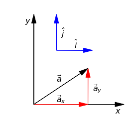

```python
avector_options = {'head_width':0.05, 'head_length':0.1, 'fc':'r', 'ec':'r', 'length_includes_head':True}

ax = plt.axes()

ax.arrow(0,0,1.0,0, **vector_options)
text(0.9, -0.1, '$x$', fontsize=16)
ax.arrow(0,0,0,1.0, **vector_options)
text(-0.1, 0.9, '$y$', fontsize=16)

ax.arrow(0.6,0,0,0.4, **avector_options)
text(0.25, 0.025, r'$\vec{a}_x$', fontsize=16)
ax.arrow(0,0,0.6,0, **avector_options)
text(0.65, 0.15, r'$\vec{a}_y$', fontsize=16)

ax.arrow(0,0,0.6,0.4, **vector_options)
text(0.25, 0.25, r'$\vec{a}$', fontsize=16)

ax.arrow(0.25,0.6,0,0.3, **uvector_options)
text(0.45, 0.625, '$\hat{i}$', fontsize=16)
ax.arrow(0.25,0.6,0.3,0, **uvector_options)
text(0.3, 0.75, '$\hat{j}$', fontsize=16)

xlim(-0.1,1.1)
ylim(-0.1,1.1)
axis('off')
ax.set_aspect('equal')
```

## Outras representações

- Os componentes de $\vec{a} = a_x\hat{i} + a_y\hat{j} = (a_x, a_y)$ são $\begin{cases} a_{x}=a \cos\theta\\ a_{y}=a \sin\theta \end{cases}$.
- Módulo e direção de $\vec{a}$: $\begin{cases} a=\sqrt{a^2_x+a^2_y}\\ \tan\theta = \frac{a_y}{a_x} \end{cases}$.
- $a_x, a_y$ e $a, \theta$ são descrições complementares
- Breve revisão sobre trigonometria no livro!

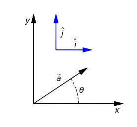

```python
ax = plt.axes()

ax.arrow(0,0,1.0,0, **vector_options)
text(0.9, -0.1, '$x$', fontsize=16)
ax.arrow(0,0,0,1.0, **vector_options)
text(-0.1, 0.9, '$y$', fontsize=16)

ax.arrow(0,0,0.6,0.4, **vector_options)
text(0.25, 0.25, r'$\vec{a}$', fontsize=16)

a = Arc(xy=(0,0), width=1, height=1, angle=0, theta1=0, theta2=35, linestyle='dashed')
ax.add_artist(a)
text(0.5, 0.12, r'$\theta$', fontsize=16)

ax.arrow(0.25,0.6,0,0.3, **uvector_options)
text(0.45, 0.625, '$\hat{i}$', fontsize=16)
ax.arrow(0.25,0.6,0.3,0, **uvector_options)
text(0.3, 0.75, '$\hat{j}$', fontsize=16)

xlim(-0.1,1.1)
ylim(-0.1,1.1)
axis('off')
ax.set_aspect('equal')
```

## Soma de vetores usando álgebra

- $\vec{r}=\vec{a}+\vec{b}\longrightarrow$ $r_x\hat{i}+r_y\hat{j}=a_x\hat{i}+a_y\hat{j}+b_x\hat{i}+b_y\hat{j}$
- \begin{eqnarray} r_x &= a_x+b_x,\\ r_y &= a_y+b_y. \end{eqnarray}
- Especialmente útil para somas de vários vetores.
- Mais simples que método gráfico.
- Módulo e direção podem ser obtidos ao final.

## Produto escalar

- (vetor)$\cdot$(vetor) = (escalar), ou "número".
- Definição: $\vec{a}\cdot\vec{b}=a b \cos\theta$
- Qual o comprimento de $\vec{a}$ ao longo de $\vec{b}$?
- Propriedades: $\vec{a}\cdot\vec{a}=$$a^2 \cos0 = a^2$, vetores perpendiculares têm produto escalar nulo, e$\begin{cases} \hat{i}\cdot\hat{j}=\hat{j}\cdot\hat{i}=0\\ \hat{i}\cdot\hat{i}=\hat{j}\cdot\hat{j}=1 \end{cases}$.

## Produto escalar

- Se $\begin{cases} \vec{a}=a_x\hat{i}+a_y\hat{j}\\ \vec{b}=b_x\hat{i}+b_y\hat{j} \end{cases}$, então $\vec{a}\cdot\vec{b}=$$(a_x\hat{i}+a_y\hat{j})\cdot(b_x\hat{i}+b_y\hat{j})$.
- Supondo que o produto escalar é distributivo,
- $\vec{a}\cdot\vec{b}=a_x b_x(\hat{i}\cdot\hat{i})+a_x b_y(\hat{i}\cdot\hat{j})+a_y b_x(\hat{j}\cdot\hat{i})+a_y b_y(\hat{j}\cdot\hat{j})$

  $$\vec{a}\cdot\vec{b}=a_x b_x+a_y b_y$$

## Exemplo

$\begin{cases} \hat{a}=3\hat{i}-4\hat{j}\\ \hat{b}=-2\hat{i}+2\hat{j} \end{cases}$. Calcular

(b) Qual o ângulo entre $\vec{a}+2\vec{b}$ e o eixo x?

(b) $\vec{a}+2\vec{b} = 3\hat{i}-4\hat{j}+2(-2\hat{i}+2\hat{j}) = -\hat{i}$.

$\theta=180^o$.

## Capítulo 4 - Movimento em 2 e 3 dimensões